# FML Assignment 2

Harshith Kumar Yadav Temura

10-01-2023

**loading the libraries**

```r
library(class)
library(caret)
library(e1071)
```

**loading the data**

```r
Bank = read.csv("C:\\Users\\Harshith Kumar\\OneDrive\\Desktop\\fml\\UniversalBank (1).csv")
dim(Bank)
```

```
## [1] 5000   14
```

```r
t(t(names(Bank)))
```

```
##       [,1]
##  [1,] "ID"
##  [2,] "Age"
##  [3,] "Experience"
##  [4,] "Income"
##  [5,] "ZIP.Code"
##  [6,] "Family"
##  [7,] "CCAvg"
##  [8,] "Education"
##  [9,] "Mortgage"
## [10,] "Personal.Loan"
## [11,] "Securities.Account"
## [12,] "CD.Account"
## [13,] "Online"
## [14,] "CreditCard"
```

**Drop ID and ZIP**

```r
Bank = Bank[,-c(1,5)]
```

**conversion of factor(Education)**

```r
#Only Education needs to be converted into Factor in dataset
Bank$Education = as.factor(Bank$Education)
levels(Bank$Education)
```

```
## [1] "1" "2" "3"
```

```r
#Now, Convert Education to Dummy Variables

groups = dummyVars(~.,data = Bank) #This created a dummy variable

Bank.Mod = as.data.frame(predict(groups,Bank))
```

**To have a consistent random selection we are setting up the value of set seed to 5**

```r
set.seed(5)

training.dif = sample(row.names(Bank.Mod),0.6*dim(Bank.Mod)[1])
validation.dif = setdiff(row.names(Bank.Mod),training.dif)
train.diff = Bank.Mod[training.dif,]
valid.diff = Bank.Mod[validation.dif,]
t(t(names(train.diff)))
```

```
##       [,1]
##  [1,] "Age"
##  [2,] "Experience"
##  [3,] "Income"
##  [4,] "Family"
##  [5,] "CCAvg"
##  [6,] "Education.1"
##  [7,] "Education.2"
##  [8,] "Education.3"
##  [9,] "Mortgage"
## [10,] "Personal.Loan"
## [11,] "Securities.Account"
## [12,] "CD.Account"
## [13,] "Online"
## [14,] "CreditCard"
```

```r
#Second approach

library(caTools)
set.seed(1)
split <- sample.split(Bank.Mod, SplitRatio = 0.6)
train_set <- subset(Bank.Mod, split == TRUE)
valid_set <- subset(Bank.Mod, split == FALSE)

# Printing the sizes of the training and validation datasets.
print(paste("The size of the training set is:", nrow(train_set)))
```

```
## [1] "The size of the training set is: 2858"
```

```r
print(paste("The size of the validation set is:", nrow(valid_set)))
```

```
## [1] "The size of the validation set is: 2142"
```

**Normalization of the dataset**

```r
train.normal.diff <- train.diff[,-10] # Note that Personal Income is the 10th variable
valid.normal.diff <- valid.diff[,-10]

normal.values <- preProcess(train.diff[, -10], method=c("center", "scale"))
train.normal.diff <- predict(normal.values, train.diff[, -10])
valid.normal.diff <- predict(normal.values, valid.diff[, -10])
```

**Question No:1**

Consider the following customer:

1. Age = 40, Experience = 10, Income = 84, Family = 2, CCAvg = 2, Education_1 = 0, Education_2 = 1, Education_3 = 0, Mortgage = 0, Securities Account = 0, CD Account = 0, Online = 1, and Credit Card = 1. Perform a k-NN classification with all predictors except ID and ZIP code using k = 1. Remember to transform categorical predictors with more than two categories into dummy variables first. Specify the success class as 1 (loan acceptance), and use the default cutoff value of 0.5. How would this customer be classified?

```r
# We have converted all categorical variables to dummy variables
# Let's create a new sample
New_CustomerX <- data.frame(
  Age = 40,
  Experience = 10,
  Income = 84,
  Family = 2,
  CCAvg = 2,
  Education.1 = 0,
  Education.2 = 1,
  Education.3 = 0,
  Mortgage = 0,
  Securities.Account = 0,
  CD.Account = 0,
  Online = 1,
  CreditCard = 1
)

# Normalize the new customer
New.Cust.normal <- New_CustomerX
New.Cust.normal <- predict(normal.values, New.Cust.normal)
```

**prediction using KNN**

```r
KNN.Prediction1 <- class::knn(train = train.normal.diff,
                       test = New.Cust.normal,
                       cl = train.diff$Personal.Loan, k = 1)
KNN.Prediction1
```

```
## [1] 0
## Levels: 0 1
```

2. What is a choice of K that balances between over-fitting and ignoring the predictor information?

```r
#Calculating the accuracy for each value of k
#Set the range of k values

accuracy.diff <- data.frame(k = seq(1, 15, 1), overallaccuracy = rep(0, 15))
for(i in 1:15) {
  KNN.Predct <- class::knn(train = train.normal.diff,
                         test = valid.normal.diff,
                         cl = train.diff$Personal.Loan, k = i)
  accuracy.diff[i, 2] <- confusionMatrix(KNN.Predct,
                                    as.factor(valid.diff$Personal.Loan),positive = "1")$overall[1]
}

which(accuracy.diff[,2] == max(accuracy.diff[,2]))
```

```
## [1] 3
```

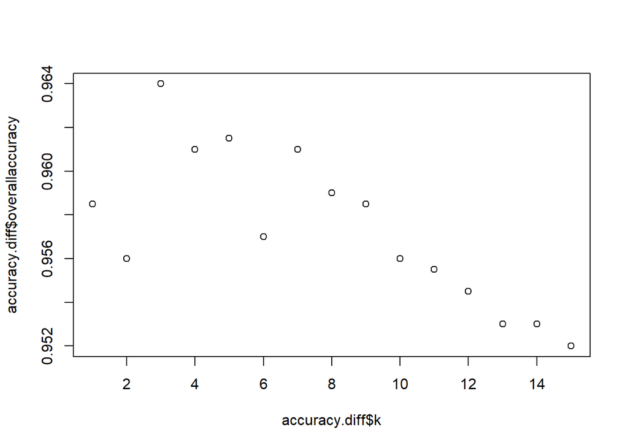

```r
plot(accuracy.diff$k,accuracy.diff$overallaccuracy)
```

**Question 3**

**3. Show the confusion matrix for the validation data that results from using the best k**

```r
KNN.Prediction2 <- class::knn(train = train.normal.diff,
                         test = valid.normal.diff,
                         cl = train.diff$Personal.Loan, k = 3)

confusionMatrix(KNN.Prediction2,as.factor(valid.diff$Personal.Loan))
```

```
## Confusion Matrix and Statistics
##
##           Reference
## Prediction    0    1
##          0 1815   67
##          1    5  113
##
##                Accuracy : 0.964
##                  95% CI : (0.9549, 0.9717)
##     No Information Rate : 0.91
##     P-Value [Acc > NIR] : < 2.2e-16
##
##                   Kappa : 0.7398
##
##  Mcnemar's Test P-Value : 6.531e-13
##
##             Sensitivity : 0.9973
##             Specificity : 0.6278
##          Pos Pred Value : 0.9644
##          Neg Pred Value : 0.9576
##              Prevalence : 0.9100
##          Detection Rate : 0.9075
##    Detection Prevalence : 0.9410
##       Balanced Accuracy : 0.8125
##
##        'Positive' Class : 0
##
```

**Question 4**

**Consider the following customer: Age = 40, Experience = 10, Income = 84, Family = 2, CCAvg = 2, #Education_1 = 0, Education_2 = 1, Education_3 = 0, Mortgage = 0, Securities Account = 0, CD #Account = 0, Online = 1 and Credit Card = 1. Classify the customer using the best k**

```r
#Classifying the customer using the best K.

New_CustomerY = data.frame(
  Age = 40,
  Experience = 10,
  Income = 84,
  Family = 2,
  CCAvg = 2,
  Education.1 = 0,
  Education.2 = 1,
  Education.3 = 0,
  Mortgage = 0,
  Securities.Account = 0,
  CD.Account = 0,
  Online = 1,
  CreditCard = 1
)

KNN.Prediction3 <- class::knn(train = train.normal.diff,
                         test = New_CustomerY,
                         cl = train.diff$Personal.Loan, k = 3)

KNN.Prediction3
```

```
## [1] 1
## Levels: 0 1
```

```r
#The customer has been classified as approved for personal loan
```

**Question5**

```r
set.seed(5)
#Let's take 50% of the entire modified data as Training data
train.diff2 = sample(row.names(Bank.Mod), 0.5*dim(Bank.Mod)[1])

#Let's take 30% of the data from the remaining 50% as Validation Data
valid.diff2 = sample(setdiff(row.names(Bank.Mod), train.diff2), 0.3*dim(Bank.Mod)[1])

#Let's take remaining 20% of the modified data as Test Data
test.diff2 = setdiff(row.names(Bank.Mod), union(train.diff2,valid.diff2))

train.normal.diff2 = Bank.Mod[train.diff2,]
valid.normal.diff2 = Bank.Mod[valid.diff2,]
test.normal.diff2 = Bank.Mod[test.diff2,]

#transporting the data
t(t(names(train.normal.diff2)))
```

```
##       [,1]
##  [1,] "Age"
##  [2,] "Experience"
##  [3,] "Income"
##  [4,] "Family"
##  [5,] "CCAvg"
##  [6,] "Education.1"
##  [7,] "Education.2"
##  [8,] "Education.3"
##  [9,] "Mortgage"
## [10,] "Personal.Loan"
## [11,] "Securities.Account"
## [12,] "CD.Account"
## [13,] "Online"
## [14,] "CreditCard"
```

```r
# Applying the k-NN method with the chosen value K.

trainknn2 = knn(train = train.normal.diff2[,-8], test = train.normal.diff2[,-8], cl = train.normal.diff2[,8], k=3)

validknn2 = knn(train = train.normal.diff2[,-8], test = valid.normal.diff2[,-8], cl = train.normal.diff2[,8], k=3)

testknn2 = knn(train = train.normal.diff2[,-8], test = test.normal.diff2[,-8], cl = train.normal.diff2[,8], k=3)
```

```r
Confusionmatrix_trainknn2 = confusionMatrix(trainknn2, as.factor(train.normal.diff2$Personal.Loan),positive = "1")

Confusionmatrix_trainknn2
```

```
## Confusion Matrix and Statistics
##
##           Reference
## Prediction    0    1
##          0 1678  205
##          1  563   54
##
##                Accuracy : 0.6928
##                  95% CI : (0.6743, 0.7108)
##     No Information Rate : 0.8964
##     P-Value [Acc > NIR] : 1
##
##                   Kappa : -0.0265
##
##  Mcnemar's Test P-Value : <2e-16
##
##             Sensitivity : 0.20849
##             Specificity : 0.74877
##          Pos Pred Value : 0.08752
##          Neg Pred Value : 0.89113
##              Prevalence : 0.10360
##          Detection Rate : 0.02160
##    Detection Prevalence : 0.24680
##       Balanced Accuracy : 0.47863
##
##        'Positive' Class : 1
##
```

```r
Confusionmatrix_validknn2 = confusionMatrix(validknn2, as.factor(valid.normal.diff2$Personal.Loan),positive = "1")

Confusionmatrix_trainknn2
```

```
## Confusion Matrix and Statistics
##
##           Reference
## Prediction    0    1
##          0 1678  205
##          1  563   54
##
##                Accuracy : 0.6928
##                  95% CI : (0.6743, 0.7108)
##     No Information Rate : 0.8964
##     P-Value [Acc > NIR] : 1
##
##                   Kappa : -0.0265
##
##  Mcnemar's Test P-Value : <2e-16
##
##             Sensitivity : 0.20849
##             Specificity : 0.74877
##          Pos Pred Value : 0.08752
##          Neg Pred Value : 0.89113
##              Prevalence : 0.10360
##          Detection Rate : 0.02160
##    Detection Prevalence : 0.24680
##       Balanced Accuracy : 0.47863
##
##        'Positive' Class : 1
##
```

```r
Confusionmatrix_testknn2 = confusionMatrix(testknn2, as.factor(test.normal.diff2$Personal.Loan),positive = "1")

Confusionmatrix_trainknn2
```

```
## Confusion Matrix and Statistics
##
##           Reference
## Prediction    0    1
##          0 1678  205
##          1  563   54
##
##                Accuracy : 0.6928
##                  95% CI : (0.6743, 0.7108)
##     No Information Rate : 0.8964
##     P-Value [Acc > NIR] : 1
##
##                   Kappa : -0.0265
##
##  Mcnemar's Test P-Value : <2e-16
##
##             Sensitivity : 0.20849
##             Specificity : 0.74877
##          Pos Pred Value : 0.08752
##          Neg Pred Value : 0.89113
##              Prevalence : 0.10360
##          Detection Rate : 0.02160
##    Detection Prevalence : 0.24680
##       Balanced Accuracy : 0.47863
##
##        'Positive' Class : 1
##
```